# Heliconia IPM Practice

Eric R. Scott

2020-08-20

*Last compiled: 2020-08-27*

# 1 TODO:

- I feel like there is maybe a more sophisticated method of dealing with “zombie” plants. Take another look at Elizabeth’s lectures or whats-her-name’s paper on terrestrial orchids.
- Not sure how to incorporate overdispersion (significant random effect of `tag_number`)

# 2 Purpose

Practice constructing an IPM using (a subset of) the [Heliconia demographic data](https://github.com/embruna/HeliconiaDataPaper/tree/master/data_clean).

# 3 Load Data

```r
unique(demog$code2)
```

```
[1] "initial.tag.yr" NA
```

## 3.1 Data Dictionary

`demog`: Demography data for *Heliconia acuminatata* experiment at BDFFP

- `plot` (character):
- `habitat` (character): fragment size
- `ranch` (character): “DIM” = Dimona, “EST” = Esteio-Colosso, or “PAL” = PortoAlegre. The three ranches that make up BDFFP.
- `bdffp_reserve_no` (character): Official BDFFP reserve designation
- `ha_id_number` (numeric): A unique ID number for each plant after resolving duplicate tags and such.
- `tag_number` (numeric): plant tag# within plot (not unique)
- `row` (character): spatial location in plot
- `column` (numeric): spatial location in plot
- `year` (numeric): year of survey
- `ht` (numeric): plant height. Plants not straightened before measurement.
- `shts` (numeric): number of shoots
- `infl` (numeric): number of inflorescences
- `code.notes` (character):
  - “plant missing” = plant was not found in that survey. May not be dead, may be found in subsequent surveys.
  - “dead” = plant lost all above-ground tissue. May resprout in a subsequent year.
  - “ULY” =
  - “sdlg” = seedling, defined as a year 1 plant.
  - “tag missing” = ID tag labeling the plant was missing. Plants were given new tags and researchers did their best to match up new tag and old tag.
- `code2` (character): “initial.tag.yr” = marks the first year plant appeared in a survey. Not necessarily a seedling.

# 4 Data Wrangling

Take subset for messing around

```r
km41 <- demog %>% filter(bdffp_reserve_no == "1501") %>% select(-bdffp_reserve_no)
km41 %>% count(plot)
```

| plot | n |
| --- | --- |
| 5750 | 8293 |
| 5756 | 9447 |

Narrow down to just one plot for now

```r
km41 <- km41 %>% filter(plot == "5750")
km41 %>% count(tag_number) %>% count(n)
```

```
Storing counts in `nn`, as `n` already present in input
ℹ Use `name = "new_name"` to pick a new name.
```

| n | nn |
| --- | --- |
| 1 | 64 |
| 2 | 129 |
| 3 | 86 |
| 4 | 63 |
| 5 | 38 |
| 6 | 65 |
| 7 | 23 |
| 8 | 78 |
| 9 | 19 |
| 10 | 63 |

[output cut: 2 more lines]

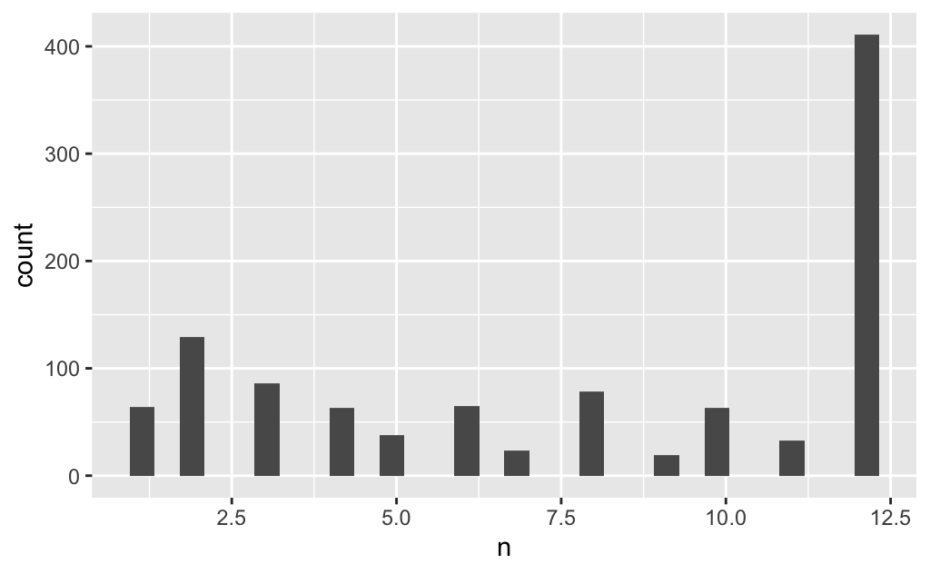

```r
km41 %>% count(tag_number) %>% ggplot() + geom_histogram(aes(n))
```

Plants have up to 12 years of data

## 4.1 Survival and reproduction

I need to have a column for fate. Made difficult by “zombie” plants.

```r
km41
```

| plot | habitat | ranch | ha_id_number | tag_number | row | column | year | ht | shts | infl | code_notes | code2 |
| --- | --- | --- | --- | --- | --- | --- | --- | --- | --- | --- | --- | --- |
| 5750 | CF | EST | 944 | 1 | I | 9 | 1998 | 80 | 3 | 1 | NA | initial.tag.yr |
| 5750 | CF | EST | 944 | 1 | I | 9 | 1999 | 84 | 4 | 0 | NA | NA |
| 5750 | CF | EST | 944 | 1 | I | 9 | 2000 | 52 | 5 | 0 | NA | NA |
| 5750 | CF | EST | 944 | 1 | I | 9 | 2001 | NA | NA | NA | plant missing (60) | NA |
| 5750 | CF | EST | 944 | 1 | I | 9 | 2002 | NA | NA | NA | plant missing (60) | NA |
| 5750 | CF | EST | 944 | 1 | I | 9 | 2003 | NA | NA | NA | plant missing (60) | NA |
| 5750 | CF | EST | 944 | 1 | I | 9 | 2004 | 15 | 1 | 0 | NA | NA |
| 5750 | CF | EST | 944 | 1 | I | 9 | 2005 | 21 | 2 | 0 | NA | NA |
| 5750 | CF | EST | 944 | 1 | I | 9 | 2006 | 25 | 1 | NA | NA | NA |
| 5750 | CF | EST | 944 | 1 | I | 9 | 2007 | 34 | 2 | NA | NA | NA |

[output cut: 990 more lines]

When is a plant really dead? When it’s the last non-`NA` value for that particular tag number before the max date.

```r
max(km41$year)
```

```
[1] 2009
```

```r
km41_2 <-
  km41 %>%
  group_by(ha_id_number) %>%
  # Routine for figuring out last year of data collected
  mutate(x = cumsum(ht > 0 & !is.na(ht))) %>%
  # mutate(x = cumsum(lag(ht) > 0 & !is.na(lag(ht)))) %>%
  mutate(n = 1:n()) %>%
  mutate(fate = if_else(
    n == which.max(x==max(x)),
    "died",
    NA_character_
  )) %>%
  # remove rows after plant is dead
  filter(row_number() <= which(fate == "died")[1]) %>%
  # remove "died" if last year of data (2009)
  ungroup() %>%
  mutate(fate = if_else(year == max(year), NA_character_, fate)) %>%
  select(-n, -x)
# km41_2 %>% filter(fate == "died") %>% count(year)
```

```r
km41_2 %>% count(fate)
```

| fate | n |
| --- | --- |
| died | 362 |
| NA | 7182 |

362 plants died

```r
km41_2 <- km41_2 %>% mutate(surv = ifelse(is.na(fate), 1, 0))
```

```r
km41_2 <- km41_2 %>% mutate(flowered = infl > 0)
```

## 4.2 Just flowering individuals

```r
km41_flowered <- km41 %>% filter(infl > 0)
```

## 4.3 Lagged height for growth

| plot | habitat | ranch | ha_id_number | tag_number | row | column | year | ht | shts | infl | code_notes | code2 | fate | surv | flowered | ht_prev |
| --- | --- | --- | --- | --- | --- | --- | --- | --- | --- | --- | --- | --- | --- | --- | --- | --- |
| 5750 | CF | EST | 944 | 1 | I | 9 | 1998 | 80 | 3 | 1 | NA | initial.tag.yr | NA | 1 | TRUE | NA |
| 5750 | CF | EST | 944 | 1 | I | 9 | 1999 | 84 | 4 | 0 | NA | NA | NA | 1 | FALSE | 80 |
| 5750 | CF | EST | 944 | 1 | I | 9 | 2000 | 52 | 5 | 0 | NA | NA | NA | 1 | FALSE | 84 |
| 5750 | CF | EST | 944 | 1 | I | 9 | 2001 | NA | NA | NA | plant missing (60) | NA | NA | 1 | NA | 52 |
| 5750 | CF | EST | 944 | 1 | I | 9 | 2002 | NA | NA | NA | plant missing (60) | NA | NA | 1 | NA | NA |
| 5750 | CF | EST | 944 | 1 | I | 9 | 2003 | NA | NA | NA | plant missing (60) | NA | NA | 1 | NA | NA |
| 5750 | CF | EST | 944 | 1 | I | 9 | 2004 | 15 | 1 | 0 | NA | NA | NA | 1 | FALSE | NA |
| 5750 | CF | EST | 944 | 1 | I | 9 | 2005 | 21 | 2 | 0 | NA | NA | NA | 1 | FALSE | 15 |
| 5750 | CF | EST | 944 | 1 | I | 9 | 2006 | 25 | 1 | NA | NA | NA | NA | 1 | NA | 21 |
| 5750 | CF | EST | 944 | 1 | I | 9 | 2007 | 34 | 2 | NA | NA | NA | NA | 1 | NA | 25 |

[output cut: 990 more lines]

# 5 IPM

Gotta look this up, but assuming that reproduction happens before survival

## 5.1 Kernel

In words:

The number of individuals in a size class in year t+1 is a function of

$$K(z^\prime,z) = p_b(z)b(z)p_rc_0(z^\prime) + s(z)G(z, z^\prime)$$
Reporduction:

- $p_b(z)$: probability of flowering as a function of size
- $b(z)$: number of inflorescences as a function of size.
- $p_r$ mean # of seedlings produced per inflorescence. This varies by year, not sure how to incorporate environmental stochasticity.
- $c_0(z^\prime)$ size distribution of new recruits

Growth & survival:

- $s(z)$ is survival probability as a function of size
- $G(z, z^\prime)$ is growth as a function of size.

## 5.2 Reproduction

In this particular dataset the only information on reproduction is number of inflorescences per plant and total number of seedlings in a year. However, Bruna et al. 2004 has some additional data on reproduction:

- each inflorescence has 20–25 flowers
- proportion of flowers developing into fruits = 0.30±0.24 (range = 0–0.88)
- Number of seeds per plant = 4.74±6.10 (range = 0–27)
- Number of sees per fruit = 1, 2, or 3 with equal probability.
- Number of seeds per flower = 0.27±0.33 (range = 0–1)

But the last step, seedlings per seed, isn’t there, so I’m not sure if this info is relevant for this IPM, especially if none of the above vital rates is expected to differ by plant size.

### 5.2.1 Probability of flowering

#### 5.2.1.1 Model

Start with most complex: quadratic response, environmental stochasticity, and random variation among plants.

```r
meo_pflwr2 <- glmer(flowered ~ ht + I(ht^2) + (1|ha_id_number) + (1|year), family = binomial, data = km41_2)
```

```
Some predictor variables are on very different scales: consider rescalingModel failed to converge with max|grad| = 0.115103 (tol = 0.002, component 1)Model is nearly unidentifiable: very large eigenvalue
 - Rescale variables?;Model is nearly unidentifiable: large eigenvalue ratio
 - Rescale variables?
```

Check random effects

```r
mo_pflwr2 <- glmer(flowered ~ ht + I(ht^2) + (1|ha_id_number), family = binomial, data = km41_2)
```

```
Some predictor variables are on very different scales: consider rescalingModel failed to converge with max|grad| = 0.456917 (tol = 0.002, component 1)Model is nearly unidentifiable: very large eigenvalue
 - Rescale variables?;Model is nearly unidentifiable: large eigenvalue ratio
 - Rescale variables?
```

```r
me_pflwr2 <- glmer(flowered ~ ht + I(ht^2) + (1|year), family = binomial, data = km41_2)
```

```
Some predictor variables are on very different scales: consider rescalingModel failed to converge with max|grad| = 0.206902 (tol = 0.002, component 1)Model is nearly unidentifiable: very large eigenvalue
 - Rescale variables?;Model is nearly unidentifiable: large eigenvalue ratio
 - Rescale variables?
```

```r
m_pflwr2  <-   glm(flowered ~ ht + I(ht^2), family = binomial, data = km41_2)
AICtab(meo_pflwr2, me_pflwr2, mo_pflwr2, m_pflwr2)
```

```
           dAIC  df
meo_pflwr2   0.0 5
me_pflwr2   34.8 4
mo_pflwr2  661.9 4
m_pflwr2   709.4 3
```

Keep both random effects.

Check quadratic

```r
meo_pflwr <- glmer(flowered ~ ht + (1|ha_id_number) + (1|year), family = binomial, data = km41_2)
AICtab(meo_pflwr, meo_pflwr2)
```

```
           dAIC df
meo_pflwr2  0.0 5
meo_pflwr  45.8 4
```

Keep quadratic

```
the hat matrix may not make sense for GLMMsthe hat matrix may not make sense for GLMMs
```

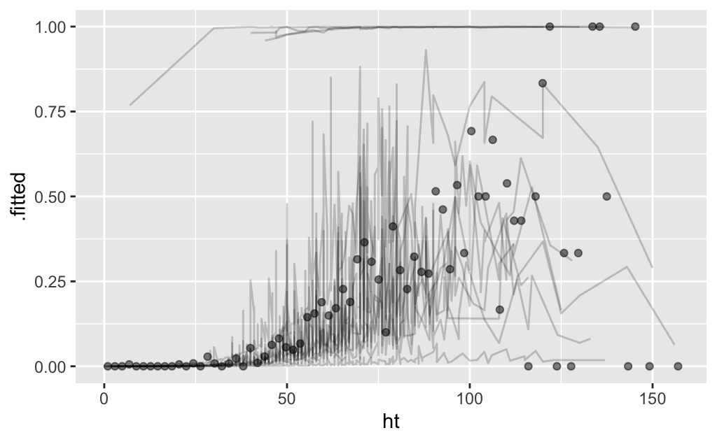

```r
augment(meo_pflwr2, type.predict = "response") %>%
  # filter(tag_number %in% c(1, 101)) %>%
  ggplot(aes(x = ht, y = .fitted)) +
  geom_line(alpha = 0.2, aes(group = year)) +
  stat_summary_bin(geom = "point", fun = mean, aes(y = as.numeric(flowered)), bins = 80, alpha = 0.5)
```

#### 5.2.1.2 Function

```r
fixef(meo_pflwr2)
```

```
  (Intercept)            ht       I(ht^2)
-7.4232694624  0.1807343495 -0.0008327647
```

$$p(flower) = inv.logit(-7.423 + 0.181ht - 0.0008ht^2)$$

Not sure how to incorporate random effects

```r
p_bz <- function(z) {
  coefs <- fixef(meo_pflwr2)
  linear.p <- coefs[1] + coefs[2]*z + coefs[3]*z^2
  p <- 1/(1+exp(-linear.p))
  return(as.numeric(p))
}
# predict(mm_pflwr2, newdata = data.frame(ht = 20, tag_number = "new"), allow.new.levels = TRUE) %>% plogis() ==
# p_bz(20)
```

### 5.2.2 Number of infloresences

#### 5.2.2.1 Model

```r
meo_flwrs2 <- glmer(infl ~ ht + I(ht^2) + (1|ha_id_number) + (1|year), family = poisson, data = km41_flowered)
```

```
Some predictor variables are on very different scales: consider rescalingboundary (singular) fit: see ?isSingular
```

```r
me_flwrs2 <- glmer(infl ~ ht + I(ht^2) + (1|year), family = poisson, data = km41_flowered)
```

```
Some predictor variables are on very different scales: consider rescalingboundary (singular) fit: see ?isSingular
```

```r
mo_flwrs2 <- glmer(infl ~ ht + I(ht^2) + (1|ha_id_number), family = poisson, data = km41_flowered)
```

```
Some predictor variables are on very different scales: consider rescalingboundary (singular) fit: see ?isSingular
```

```r
m_flwrs2 <- glm(infl ~ ht + I(ht^2), family = poisson, data = km41_flowered)
AICtab(meo_flwrs2, me_flwrs2, mo_flwrs2, m_flwrs2)
```

```
           dAIC df
m_flwrs2   0    3
me_flwrs2  2    4
mo_flwrs2  2    4
meo_flwrs2 4    5
```

No random effects.

Check quadratic

```r
m_flwrs <- glm(infl ~ ht, family = poisson, data = km41_flowered)
AICtab(m_flwrs, m_flwrs2)
```

```
         dAIC df
m_flwrs  0    2
m_flwrs2 2    3
```

Go with simpler linear glm

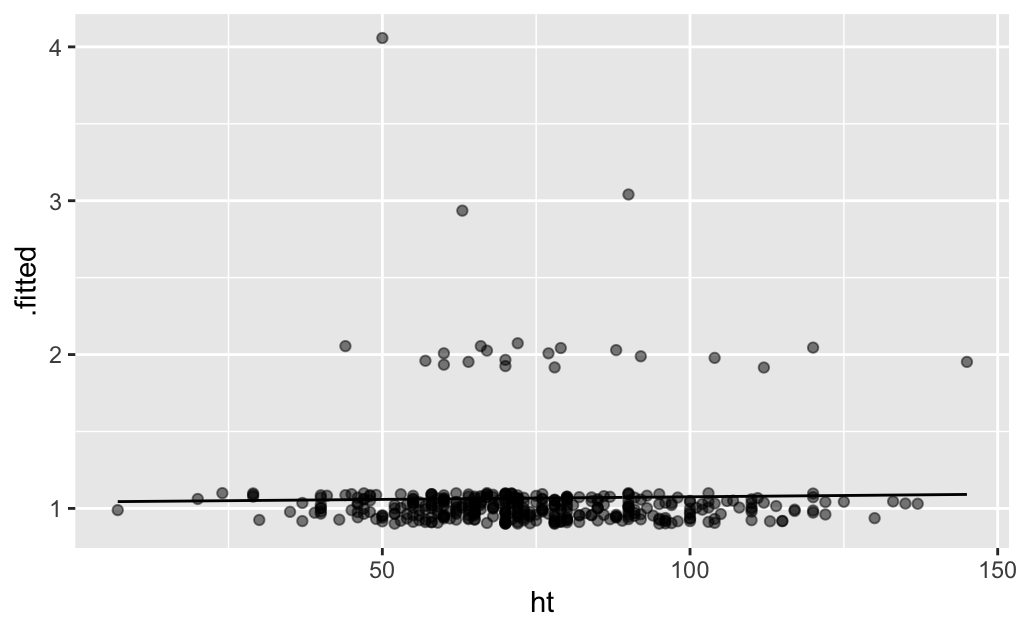

```r
augment(m_flwrs, type.predict = "response") %>%
  ggplot(aes(x = ht, y = .fitted)) +
  geom_line() +
  geom_jitter(aes(y = infl), alpha = 0.5, width = 0, height = 0.1)
```

#### 5.2.2.2 Function

```r
b_z <- function(z) {
  coefs <- coef(m_flwrs)
  infl <- coefs[1] + coefs[2]*z
  return(as.numeric(infl))
}
```

### 5.2.3 Probability of recruitment

#### 5.2.3.1 Model

Estimated as number of recruits / number of inflorescences in year prev. year

| year | recruits | seeds_est |
| --- | --- | --- |
| 1999 | 53 | 27 |
| 2000 | 105 | 18 |
| 2001 | 40 | 27 |
| 2002 | 121 | 13 |
| 2003 | 14 | 79 |
| 2004 | 74 | 2 |
| 2005 | 27 | 25 |
| 2006 | 30 | 52 |
| 2007 | 44 | 76 |
| 2008 | 53 | 27 |

[output cut: 1 more lines]

```r
m <- glm(recruits ~ 1, offset = log(seeds_est), family = poisson, data = km41_rec_sum)
coef(m)
```

```
(Intercept)
  0.5002154
```

#### 5.2.3.2 Function

```r
p_r <- as.numeric(exp(coef(m)))
p_r
```

```
[1] 1.649077
```

So like 1.64 seedlings per inflorescence

### 5.2.4 Size distribution of new recruits

#### 5.2.4.1 Model

recruitment size

```r
km41_rec <- km41 %>% filter(code_notes == "sdlg (1)")
m_rec <- lm(ht ~ 1, data = km41_rec)
```

```r
coef(m_rec)
```

```
(Intercept)
     9.3328
```

```r
summary(m_rec)$sigma
```

```
[1] 5.07141
```

#### 5.2.4.2 Function

```r
c_0z1 <- function(z1) {
  mu <- coef(m_rec)[1]
  sig <- summary(m_rec)$sigma
  p.deRecr <- dnorm(z1, mean = mu, sd = sig)
  return(p.deRecr)
}
# c_0z1(20)
```

## 5.3 Growth

### 5.3.1 Model

Try modeling growth as height_t+1 ~ height_t. Needs a random effect of tag_number, I think?

```r
meo_grow2 <- lmer(ht ~ ht_prev + I(ht_prev^2) + (1|ha_id_number) + (1|year), data = km41_2)
```

```
Some predictor variables are on very different scales: consider rescalingboundary (singular) fit: see ?isSingular
```

Test random effects

```r
me_grow2 <- lmer(ht ~ ht_prev + I(ht_prev^2) + (1|year), data = km41_2)
```

```
Some predictor variables are on very different scales: consider rescaling
```

```r
mo_grow2 <- lmer(ht ~ ht_prev + I(ht_prev^2) + (1|ha_id_number), data = km41_2)
```

```
Some predictor variables are on very different scales: consider rescalingboundary (singular) fit: see ?isSingular
```

```r
m_grow2 <- lm(ht ~ ht_prev + I(ht_prev^2), data = km41_2)
AICtab(meo_grow2, me_grow2, mo_grow2, m_grow2)
```

```
          dAIC  df
me_grow2    0.0 5
meo_grow2   2.0 6
m_grow2   220.5 4
mo_grow2  248.6 5
```

Environmental stochastsicity, but not differences among plants

check quadratic

```r
me_grow <- lmer(ht ~ ht_prev + (1|year), data = km41_2)
AICtab(me_grow, me_grow2)
```

```
         dAIC df
me_grow2  0.0 5
me_grow  72.9 4
```

Quadratic is better.

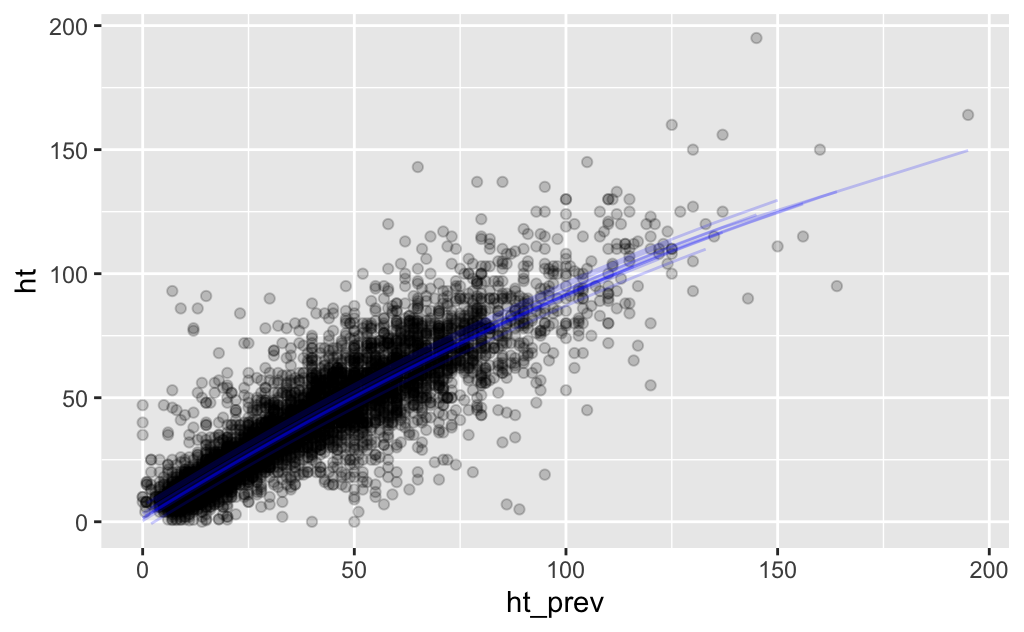

```r
augment(me_grow2) %>%
ggplot(aes(x = ht_prev, y = ht)) +
  geom_point(alpha = 0.2) +
  geom_line(aes(y = .fitted, group = year), color = "blue", alpha = 0.2)
```

### 5.3.2 Function

```r
fixef(me_grow2)
```

```
 (Intercept)      ht_prev I(ht_prev^2)
 2.153360876  1.056288438 -0.001567026
```

```r
summary(me_grow2)$sigma
```

```
[1] 11.3116
```

```r
summary(me_grow2)$varcor
```

```
 Groups   Name        Std.Dev.
 year     (Intercept)  2.5186
 Residual             11.3116
```

Not sure how to take random effect into account

```r
G_z1z <- function(z1, z) {
  coefs <- fixef(me_grow2)
  sig <- summary(me_grow2)$sigma #or shoudl this incorporate mixed effects somehow?

  mu <- coefs[1] + coefs[2]*z + coefs[3]*z^2
  p.den.grow <- dnorm(z1, mean = mu, sd = sig) #pdf of new size for current size
  return(p.den.grow)
}
```

## 5.4 Survival

### 5.4.1 Model

```r
meo_surv2 <- glmer(surv ~ ht + I(ht^2) + (1|ha_id_number) + (1|year), family = binomial, data = km41_2)
```

```
Some predictor variables are on very different scales: consider rescalingboundary (singular) fit: see ?isSingular
```

```r
me_surv2
```

```
Generalized linear mixed model fit by maximum likelihood (Laplace Approximation) ['glmerMod']
 Family: binomial  ( logit )
Formula: surv ~ ht + I(ht^2) + (1 | year)
   Data: km41_2
      AIC       BIC    logLik  deviance  df.resid
 2292.405  2320.072 -1142.202  2284.405      7452
Random effects:
 Groups Name        Std.Dev.
 year   (Intercept) 0.9141
Number of obs: 7456, groups:  year, 12
Fixed Effects:
(Intercept)           ht      I(ht^2)
  0.9184480    0.1414367   -0.0008874
fit warnings:
Some predictor variables are on very different scales: consider rescaling
convergence code 0; 0 optimizer warnings; 3 lme4 warnings
```

Check quadratic

```r
me_surv <- glmer(surv ~ ht + (1|year), family = binomial, data = km41_2)

AICtab(me_surv, me_surv2)
```

```
         dAIC df
me_surv2  0.0 4
me_surv  89.7 3
```

Quadratic is better

```
the hat matrix may not make sense for GLMMsthe hat matrix may not make sense for GLMMs
```

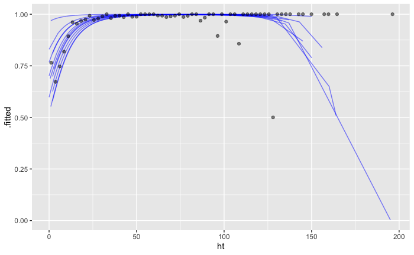

```r
augment(me_surv2, type.predict = "response") %>%
  ggplot(aes(x = ht, y = .fitted)) +
  geom_line(aes(group = year), color = "blue", alpha = 0.5) +
  stat_summary_bin(geom = "point", fun = mean, aes(y = surv), bins = 80, alpha = 0.5)
```

Survival is better in some years than others, especially for very small plants

### 5.4.2 Function

```r
fixef(me_surv2)
```

```
  (Intercept)            ht       I(ht^2)
 0.9184479820  0.1414366762 -0.0008873667
```

```r
s_z <- function(z) {
  coefs <- fixef(me_surv2)
  linear.p <- coefs[1] + coefs[2]*z + coefs[3]*z^2
  p <- 1/(1+exp(-linear.p))
  return(as.numeric(p))
}
```

# 6 Fecundity kernel

p_b(z)b(z)p_rc_0(z^)

```r
F_z1z <- function(z1, z) {
  return(p_bz(z) * b_z(z) * p_r * c_0z1(z1))
}
```

# 7 Survival kernel

s(z)G(z, z^)

```r
P_z1z <- function(z1, z) {
  return(s_z(z) * G_z1z(z, z1))
}
```

# 8 Run IPM

## 8.1 Decide meshpoints

```r
range(km41$ht[km41$ht>0], na.rm = TRUE)
```

```
[1]   0.6 195.0
```

So I’ll go from 0.4 to 200??

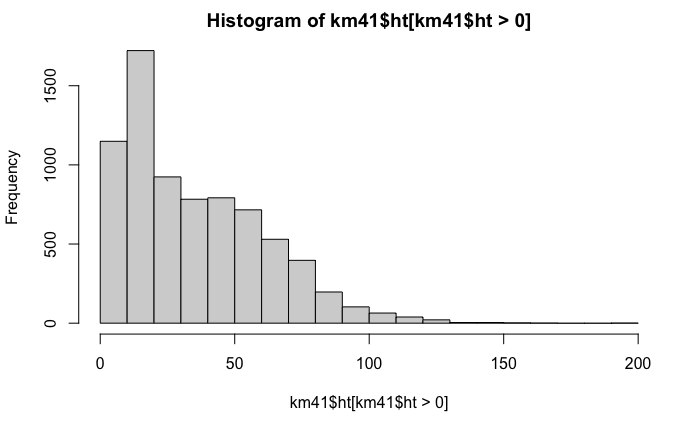

```r
hist(km41$ht[km41$ht>0])
```

## 8.2 Projection matrix

```r
mk_K <- function(m, L, U) {

    # mesh points
    h <- (U - L)/m
    meshpts <- L + ((1:m) - 1/2) * h
    P <- h * (outer(meshpts, meshpts, P_z1z))
    F <- h * (outer(meshpts, meshpts, F_z1z))
    K <- P + F
    return(list(K = K, meshpts = meshpts, P = P, F = F))
}
```

```r
out <- mk_K(100, 0.4, 200)
```

# 9 Results

```r
lambda(out$K)
```

```
[1] 1.00757
```

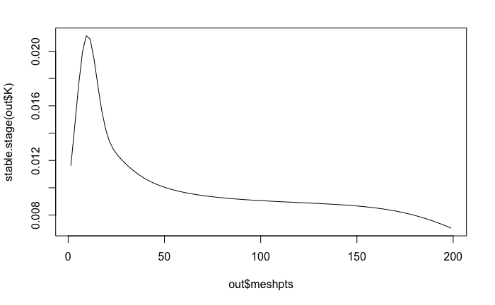

```r
plot(out$meshpts, stable.stage(out$K), type = "l")
```

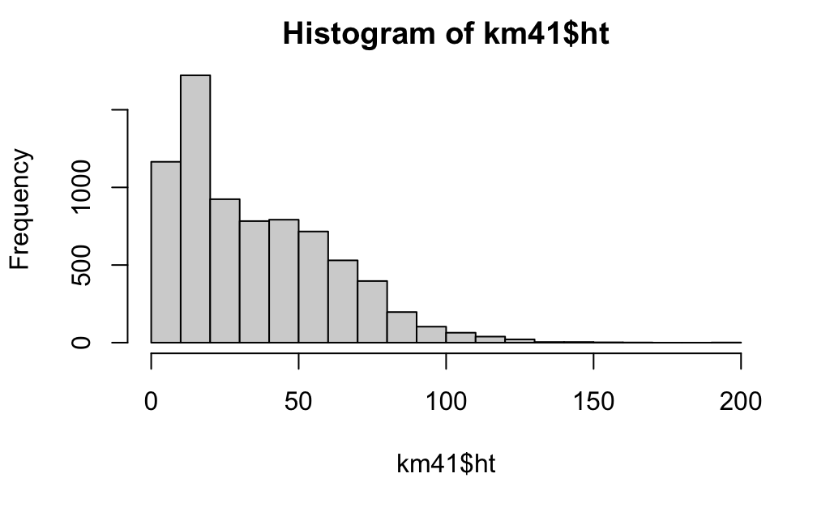

```r
hist(km41$ht)
```

Kinda matches?

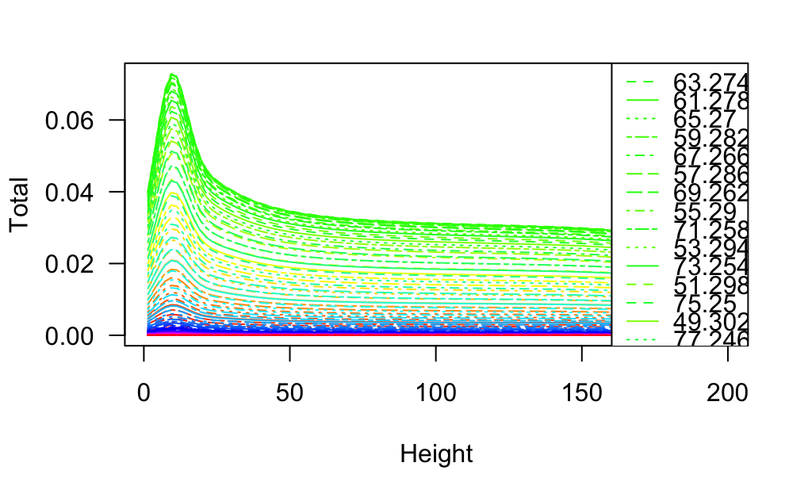

Can’t remember how to interpret this

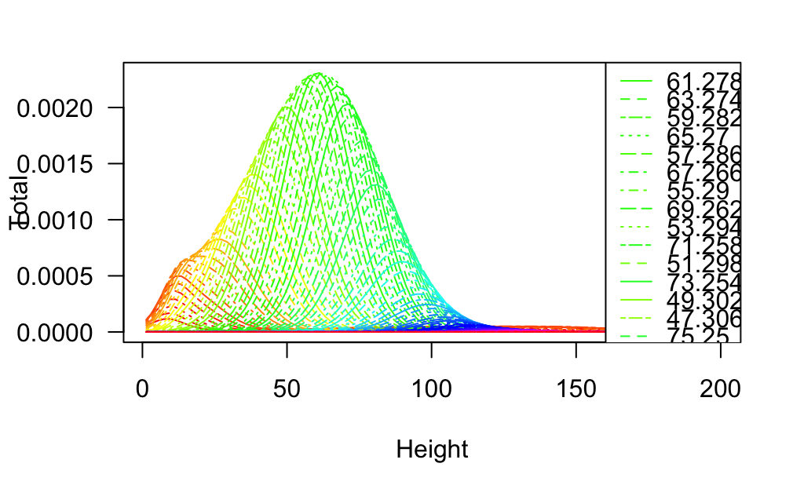